# Project 3 Markdown

Aneesa Sunderji, Kusoom Ochani, Purva Mashru

2025-03-23

# Introduction

In this project, we combine descriptive and predictive analytics to gather insights about the film industry. The focus of our analysis will be on linear regression models, which will be used to forecast values of the dependent variable revenue based on input values of independent variables.

### Key Objectives

1. Understand the movie market
2. Determine factors impacting box-office financial performance
3. Develop recommendations to increase revenue

# Data Overview and Clean-up

Before we start working with data, we need to set up our environment.  
Our pre-processing and clean-up of the data is a 13-step process.

It consists of:

- Setting the working directory, loading libraries, and loading datasets;
- Standardizing column names, cleaning text data, merging the datasets, and checking for missing values;
- Converting data types, handling outliers, and creating new variables;
- Regrouping genres, saving the cleaned dataset, and conducting a final check

```r
  # Step 1: Setting the working directory where our data files are stored.
  # The working directory is the location on the computer where R will look for files.
  setwd("~/School/Year 4/Winter 2024-25/1. MKTG 3P98/RStudio Files/A3")  # This is where our datasets are stored.

  # Step 2: Loading Required Libraries
  # Libraries in R are like toolkits that provide additional functions for data handling, visualization, and analysis.
  # We need the following libraries for this project:
  library(tidyverse)  # This package includes multiple useful functions for data manipulation and visualization.
  library(dplyr)      # A part of tidyverse, mainly used for filtering, summarizing, and transforming data.
  library(data.table) # Helps in handling large datasets efficiently.
  library(stringr)    # Provides tools to manipulate text (e.g., trimming unnecessary spaces).
  library(openxlsx)   # Allows us to read and write Excel files.
```

```r
  library(ggplot2)    # Used for creating graphs and visualizations.
  library(performance)# Used for checking regression assumptions
  # Step 3: Loading and Inspecting Datasets
  # This project includes two datasets:
  # 1. Financial Data: Contains information about movie budgets and revenue.
  # 2. Audience Data: Includes information such as IMDb ratings, critic scores, and Facebook likes.
  # We will load both datasets before merging them into one.

  financials <- read.xlsx("Movie Dataset_Financials.xlsx", sheet = "Sheet1")  # Load financial dataset
  audience <- read.xlsx("Movie Dataset_General Audience.xlsx", sheet = "Sheet 1")  # Load audience dataset (with a space in the sheet name)

  # Let's check the structure of both datasets to understand what kind of data we have.
  glimpse(financials)  # This function shows column names, data types, and sample values.
```

```
## Rows: 651
## Columns: 5
## $ original_title       <chr> "The Departed ", "Exodus: Gods and Kings ", "Spec…
## $ `budget.(Millions)`  <dbl> 1.00, 2.00, 110.00, 2.90, 190.00, 135.00, 1.00, 2…
## $ `revenue.(Millions)` <dbl> 0.009318, 0.045431, 295.238201, 0.296557, 1506.24…
## $ language             <chr> "English", "English", "English", "English", "Fren…
## $ country              <chr> "USA", "UK", "UK", "USA", "France", "USA", "USA",…
```

```r
  glimpse(audience)    # Helps us understand what information is available in the audience dataset.
```

```
## Rows: 651
## Columns: 13
## $ original_title  <chr> "The Departed ", "Exodus: Gods and Kings ", "Spectre "…
## $ type            <chr> "Feature Film", "Feature Film", "Feature Film", "Featu…
## $ genre           <chr> "Drama", "Drama", "Comedy", "Drama", "Horror", "Docume…
## $ runtime         <dbl> 118, 131, 84, 97, 90, 78, 107, 130, 88, 100, 127, 110,…
## $ mpaa_rating     <chr> "Unrated", "PG-13", "R", "PG", "R", "Unrated", "R", "R…
## $ imdb_rating     <dbl> 2.1, 3.3, 7.6, 2.5, 7.2, 7.8, 2.1, 2.1, 7.5, 4.1, 6.8,…
## $ imdb_num_votes  <dbl> 9904, 1010, 22381, 54363, 35096, 333, 9904, 122980, 88…
## $ critics_rating  <chr> "Fresh", "Fresh", "Certified Fresh", "Rotten", "Certif…
## $ critics_score   <dbl> 10, 43, 91, 27, 81, 91, 30, 33, 90, 56, 89, 30, 30, 45…
## $ audience_rating <chr> "Upright", "Upright", "Upright", "Upright", "Upright",…
## $ audience_score  <dbl> 21, 34, 91, 23, 77, 86, 21, 31, 89, 45, 75, 21, 39, 53…
## $ best_pic_nom    <chr> "no", "no", "no", "no", "no", "no", "no", "no", "no", …
## $ Facebook_Likes  <dbl> 48, 490, 11700, 230, 172221, 211873, 171, 355, 292000,…
```

```r
  # Step 4: Standardizing Column Names
  # Before merging the datasets, we must ensure that column names are consistent.
  # If the column names are different in the two datasets, merging will not work correctly.

  financials <- financials |>
    rename(
      title = "original_title",  # Changing "original_title" to "title" for consistency.
      budget = "budget.(Millions)",  # Standardizing the budget column.
      revenue = "revenue.(Millions)"  # Standardizing the revenue column.
    )

  audience <- audience |>
    rename(title = "original_title")  # Making sure "title" is the same in both datasets.

  # Step 5: Cleaning Text Data (Trimming Spaces and Removing Duplicates)
  # Sometimes, data might contain extra spaces before or after text values, which can cause issues when merging.
  # We will use functions to remove these unnecessary spaces and also eliminate duplicate movie titles.

  financials <- financials |>
    mutate(
      title = str_trim(title),  # Removes spaces at the beginning and end of movie titles.
      title = str_squish(title)  # Removes extra spaces between words.
    ) |>
    filter(!duplicated(title))  # Removes duplicate movie entries.

  audience <- audience |>
    mutate(
      title = str_trim(title),
      title = str_squish(title)
    ) |>
    filter(!duplicated(title))

  # Step 6: Merging the Two Datasets
  # Now that the text data is cleaned, we can combine both datasets into one.
  # The function `left_join()` is used to merge datasets based on a common column.
  # We use "title" as the common column since it represents the movie name.

  df <- left_join(audience, financials, by = "title")

  # Step 7: Checking for Missing Values
  # Missing values can create problems in analysis. We check for missing values in key columns.

  colSums(is.na(df))  # This function counts how many missing values exist in each column.
```

```
##           title            type           genre         runtime     mpaa_rating
##               0               0               0               1               0
##     imdb_rating  imdb_num_votes  critics_rating   critics_score audience_rating
##               0               0               0               0               0
##  audience_score    best_pic_nom  Facebook_Likes          budget         revenue
##               0               0               0               0               0
##        language         country
##               1               1
```

```r
  # If a movie is missing key financial data (budget or revenue) or rating data (IMDb rating or critic score),
  # it cannot be used for meaningful analysis. We remove such rows.

  df <- df |>
    filter(!is.na(budget), !is.na(revenue), !is.na(critics_score), !is.na(imdb_rating))

  # Step 8: Converting Budget & Revenue to Numeric Data Type
  # Sometimes, numerical values are stored as text (characters) instead of actual numbers.
  # We need to make sure budget and revenue are in numeric format so that we can perform calculations.

  df <- df |>
    mutate(
      budget = as.numeric(budget),
      revenue = as.numeric(revenue)
    )

  # Step 9: Handling Outliers (Removing Extreme Revenue Values)
  # Some movies have extremely high revenue compared to others, which may distort our analysis.
  # We will remove the top 1% of revenue values to prevent misleading results.

  df <- df |>
    filter(budget > 0, revenue > 0, revenue < quantile(df$revenue, 0.99))

  # Step 10: Creating New Variables
  # In addition to the existing columns, we create new variables that can help in analysis.

  # 1. Profit Calculation
  # Profit is calculated as the difference between revenue and budget.
  df <- df |> mutate(profit = revenue - budget)

  # 2. Adjusting Critics Score Scale
  # IMDb ratings are based on a 10-point scale, while critic scores use a 100-point scale.
  # To make them comparable, we convert the critic score to a 10-point scale.

  df <- df |> mutate(critics_score_scaled = critics_score / 10)

  # 3. Calculating Average Rating
  # To combine IMDb ratings and critic scores into a single metric, we take the average.
  df <- df |> mutate(avg_rating = (critics_score_scaled + imdb_rating) / 2)

  # 4. Calculating Return on Investment (ROI)
  # ROI tells us how profitable a movie was compared to its budget.
  # The formula is: (Profit / Budget) * 100

  df <- df |> mutate(ROI = (profit / budget) * 100)

  # Step 11: Grouping Movies into Broad Genre Categories
  # The dataset has multiple genres, so we will simplify them into broader categories.

  df <- df |>
    mutate(
      genre_category = case_when(
        str_detect(genre, "Action|Adventure") ~ "Action/Adventure",
        str_detect(genre, "Comedy") ~ "Comedy",
        str_detect(genre, "Drama|Romance") ~ "Drama",
        str_detect(genre, "Horror|Thriller") ~ "Horror/Thriller",
        str_detect(genre, "Sci-Fi|Fantasy") ~ "Sci-Fi/Fantasy",
        TRUE ~ "Other"
      )
    )

  # Step 12: Saving the Cleaned Dataset
  # The cleaned data will be saved as a CSV file so that it can be used for further analysis.

  write.csv(df, "Cleaned_Movie_Data.csv", row.names = FALSE)

  # Step 13: Final Check & Confirmation Message
  # Finally, we check the structure of the cleaned dataset and print a message confirming that the process is complete.

  glimpse(df)  # Shows the final dataset structure.
```

```
## Rows: 637
## Columns: 22
## $ title                <chr> "The Departed", "Exodus: Gods and Kings", "Spectr…
## $ type                 <chr> "Feature Film", "Feature Film", "Feature Film", "…
## $ genre                <chr> "Drama", "Drama", "Comedy", "Drama", "Documentary…
## $ runtime              <dbl> 118, 131, 84, 97, 78, 107, 130, 100, 127, 110, 11…
## $ mpaa_rating          <chr> "Unrated", "PG-13", "R", "PG", "Unrated", "R", "R…
## $ imdb_rating          <dbl> 2.1, 3.3, 7.6, 2.5, 7.8, 2.1, 2.1, 4.1, 6.8, 2.1,…
## $ imdb_num_votes       <dbl> 9904, 1010, 22381, 54363, 333, 9904, 122980, 739,…
## $ critics_rating       <chr> "Fresh", "Fresh", "Certified Fresh", "Rotten", "F…
## $ critics_score        <dbl> 10, 43, 91, 27, 91, 30, 33, 56, 89, 30, 30, 45, 3…
## $ audience_rating      <chr> "Upright", "Upright", "Upright", "Upright", "Upri…
## $ audience_score       <dbl> 21, 34, 91, 23, 86, 21, 31, 45, 75, 21, 39, 53, 2…
## $ best_pic_nom         <chr> "no", "no", "no", "no", "no", "no", "no", "no", "…
## $ Facebook_Likes       <dbl> 48, 490, 11700, 230, 211873, 171, 355, 3611, 1244…
## $ budget               <dbl> 1.00, 2.00, 110.00, 2.90, 135.00, 1.00, 2.00, 2.0…
## $ revenue              <dbl> 0.009318, 0.045431, 295.238201, 0.296557, 532.950…
## $ language             <chr> "English", "English", "English", "English", "Engl…
## $ country              <chr> "USA", "UK", "UK", "USA", "USA", "USA", "USA", "U…
## $ profit               <dbl> -0.990682, -1.954569, 185.238201, -2.603443, 397.…
## $ critics_score_scaled <dbl> 1.0, 4.3, 9.1, 2.7, 9.1, 3.0, 3.3, 5.6, 8.9, 3.0,…
## $ avg_rating           <dbl> 1.55, 3.80, 8.35, 2.60, 8.45, 2.55, 2.70, 4.85, 7…
## $ ROI                  <dbl> -99.06820, -97.72845, 168.39836, -89.77390, 294.7…
## $ genre_category       <chr> "Drama", "Drama", "Comedy", "Drama", "Other", "Dr…
```

```r
  cat("Data preparation is complete. The cleaned dataset has been saved as 'Cleaned_Movie_Data.csv'\n")
```

```
## Data preparation is complete. The cleaned dataset has been saved as 'Cleaned_Movie_Data.csv'
```

# Descriptive Analysis

To understand which factors impact box office financial performance and find ways to increase revenue, we first want to understand the relationship between key variables and revenue

```r
  # Summary statistics for key variables
  summary(df[, c("revenue", "imdb_rating", "critics_score", "audience_score", "budget", "Facebook_Likes")])
```

```
##     revenue          imdb_rating     critics_score    audience_score
##  Min.   :  0.0093   Min.   : 1.200   Min.   :  5.00   Min.   :13.00
##  1st Qu.: 20.6453   1st Qu.: 4.300   1st Qu.: 37.00   1st Qu.:38.00
##  Median : 61.4590   Median : 6.100   Median : 54.00   Median :55.00
##  Mean   :124.7731   Mean   : 5.808   Mean   : 54.72   Mean   :56.38
##  3rd Qu.:150.1661   3rd Qu.: 7.000   3rd Qu.: 72.00   3rd Qu.:76.00
##  Max.   :886.6868   Max.   :55.000   Max.   :100.00   Max.   :96.00
##      budget        Facebook_Likes
##  Min.   :  0.318   Min.   :     2
##  1st Qu.: 10.000   1st Qu.:  6946
##  Median : 25.000   Median : 25942
##  Mean   : 39.962   Mean   : 61230
##  3rd Qu.: 52.000   3rd Qu.: 81115
##  Max.   :250.000   Max.   :555609
```

```r
  # Correlation between revenue and other variables
  cor(df[, c("revenue", "imdb_rating", "critics_score", "audience_score", "budget", "Facebook_Likes")], use = "complete.obs")
```

```
##                  revenue imdb_rating critics_score audience_score    budget
## revenue        1.0000000   0.2486711     0.4030977      0.4749107 0.6812840
## imdb_rating    0.2486711   1.0000000     0.3783054      0.4797029 0.1973535
## critics_score  0.4030977   0.3783054     1.0000000      0.7703565 0.2994714
## audience_score 0.4749107   0.4797029     0.7703565      1.0000000 0.3758337
## budget         0.6812840   0.1973535     0.2994714      0.3758337 1.0000000
## Facebook_Likes 0.7076950   0.1407699     0.2403084      0.3050564 0.4645446
##                Facebook_Likes
## revenue             0.7076950
## imdb_rating         0.1407699
## critics_score       0.2403084
## audience_score      0.3050564
## budget              0.4645446
## Facebook_Likes      1.0000000
```

```r
  ##Through this, we can see which variables are most strongly associated with revenue and any other relationships that can assist in marketing strategies, budget, and overall performance.
  ##Facebook Likes, budget, and audience scores have the strongest correlation with revenue, which means these are the key drivers we can focus on. Other relationships that have a strong positive correlation include critics scores vs. audience scores, and budget vs. Facebook Likes
```

Now we will create general data visualizations to get insights regarding the key relationships we have defined above

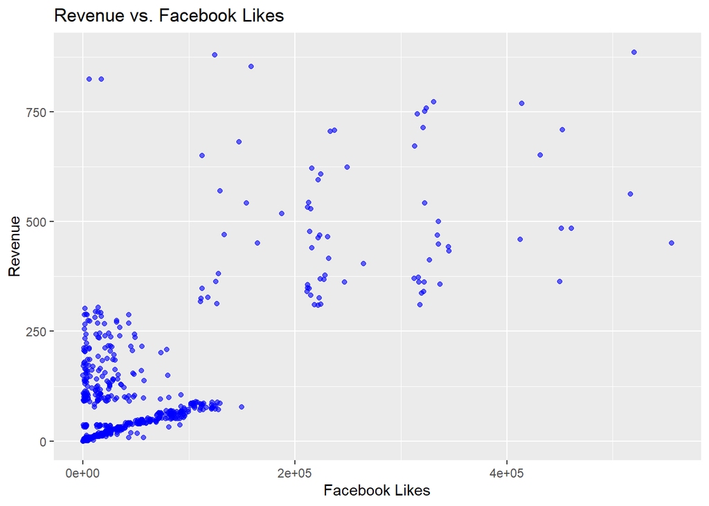

```r
#Revenue vs. Facebook Likes
  ggplot(df, aes(x = Facebook_Likes, y = revenue)) +
    geom_point(alpha = 0.6, color = "blue") +
    labs(title = "Revenue vs. Facebook Likes", x = "Facebook Likes", y = "Revenue")
```

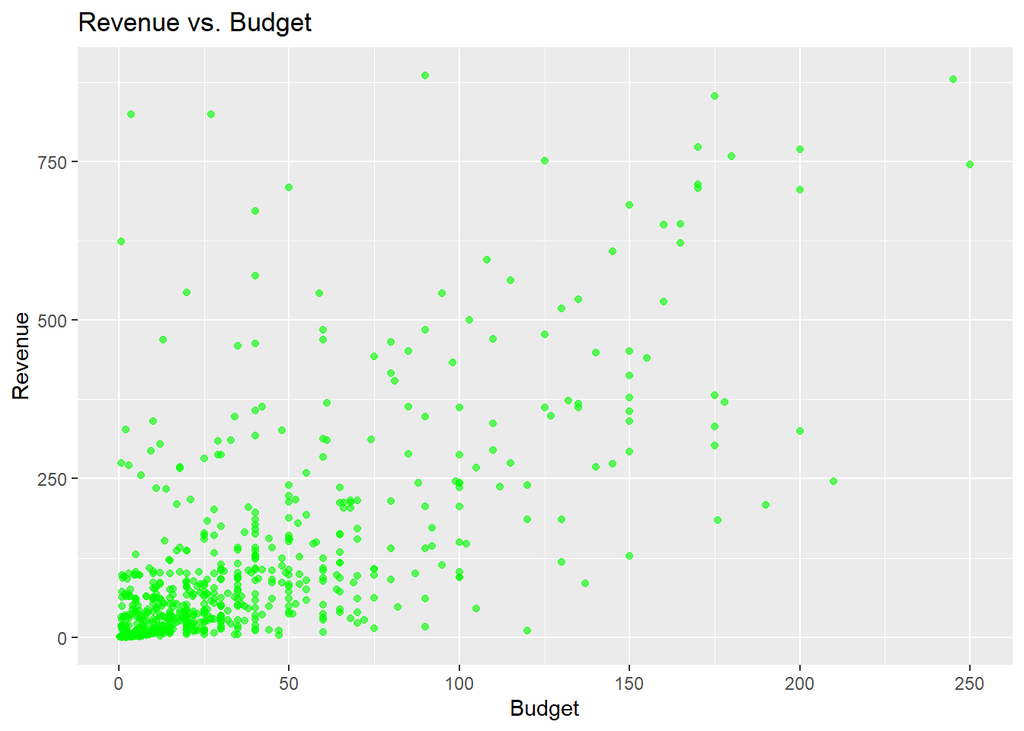

```r
  #Revenue vs. Budget
  ggplot(df, aes(x = budget, y = revenue)) +
    geom_point(alpha = 0.6, color = "green") +
    labs(title = "Revenue vs. Budget", x = "Budget", y = "Revenue")
```

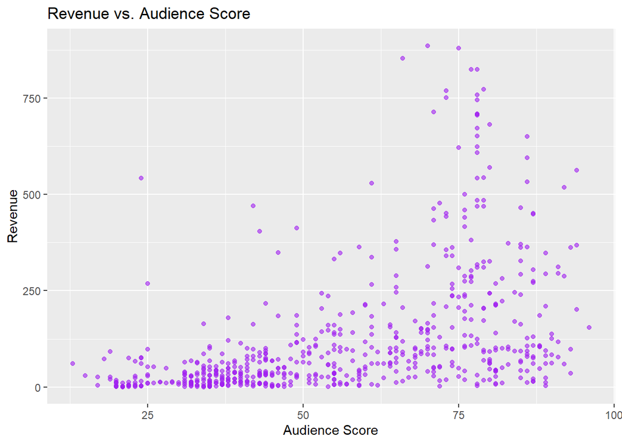

```r
  #Revenue vs. Audience scores
  ggplot(df, aes(x = audience_score, y = revenue)) +
    geom_point(alpha = 0.6, color = "purple") +
    labs(title = "Revenue vs. Audience Score", x = "Audience Score", y = "Revenue")
```

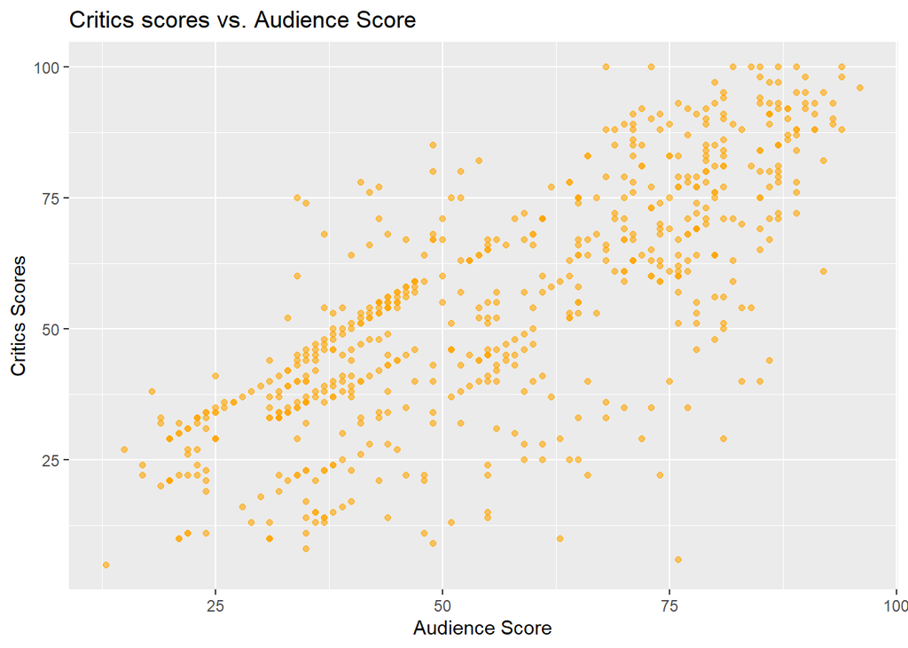

```r
  #Critics scores vs. Audience scores
  ggplot(df, aes(x = audience_score, y = critics_score)) +
    geom_point(alpha = 0.6, color = "orange") +
    labs(title = "Critics scores vs. Audience Score", x = "Audience Score", y = "Critics Scores")
```

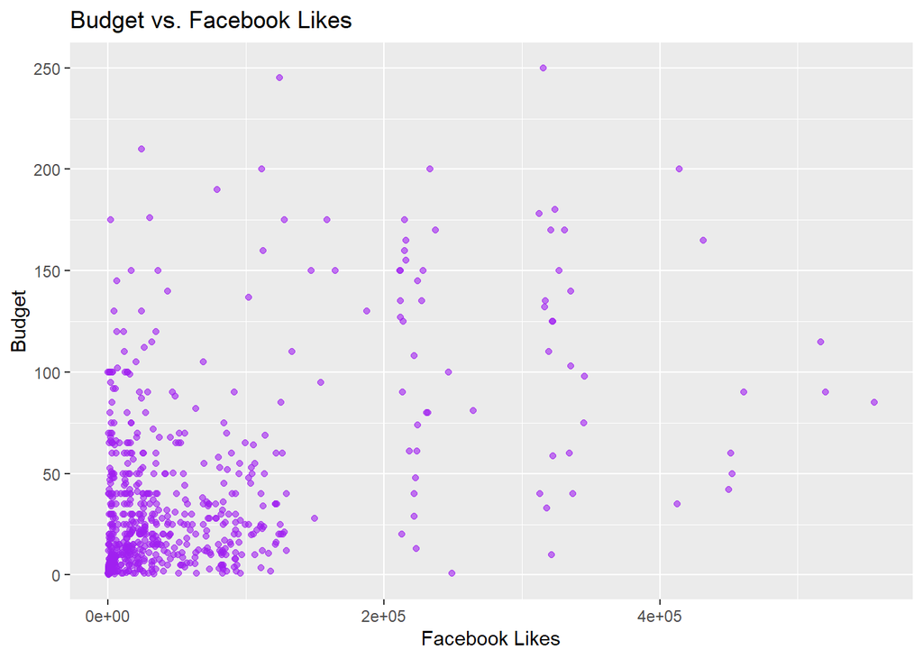

```r
  #Budget vs. Facebook Likes
  ggplot(df, aes(x = Facebook_Likes, y = budget)) +
    geom_point(alpha = 0.6, color = "purple") +
    labs(title = "Budget vs. Facebook Likes", x = "Facebook Likes", y = "Budget")
```

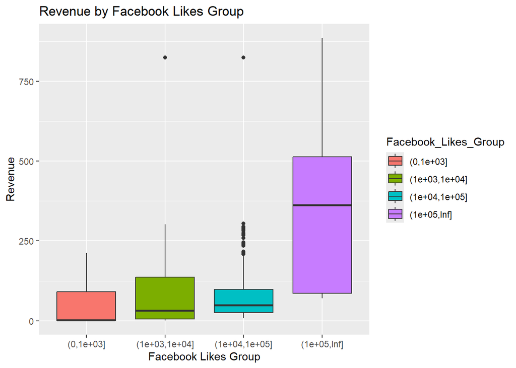

```r
 #1. Revenue by Facebook Likes
  df %>%
    mutate(Facebook_Likes_Group = cut(Facebook_Likes, breaks = c(0, 1000, 10000, 100000, Inf))) %>%

    ## Box Plot: Revenue by Facebook Likes Group
    ggplot(aes(x = Facebook_Likes_Group, y = revenue, fill = Facebook_Likes_Group)) +
    geom_boxplot() +
    labs(title = "Revenue by Facebook Likes Group", x = "Facebook Likes Group", y = "Revenue")
```

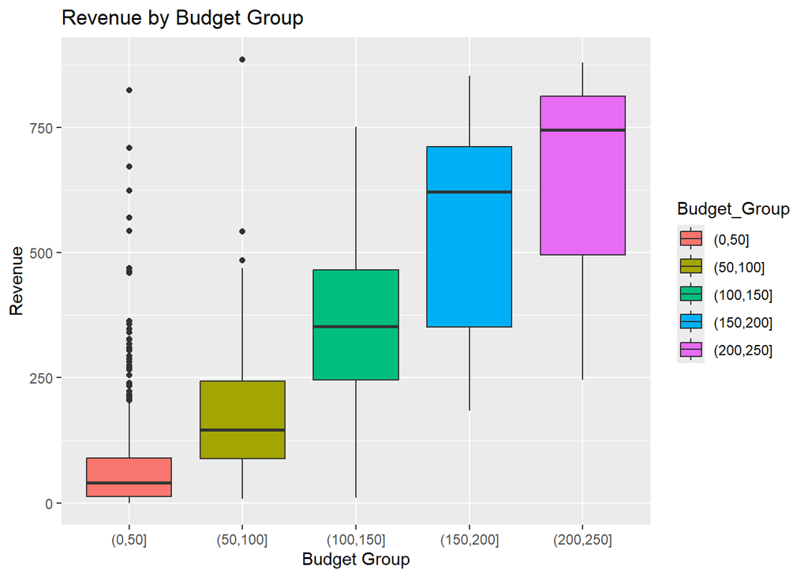

```r
  #2. Revenue by Budget
  df %>%
    mutate(Budget_Group = cut(budget, breaks = c(0, 50, 100, 150, 200, 250, Inf))) %>%

    ## Box plot: Revenue by Budget Group
    ggplot(aes(x = Budget_Group, y = revenue, fill = Budget_Group)) +
    geom_boxplot() +
    labs(title = "Revenue by Budget Group", x = "Budget Group", y = "Revenue")
```

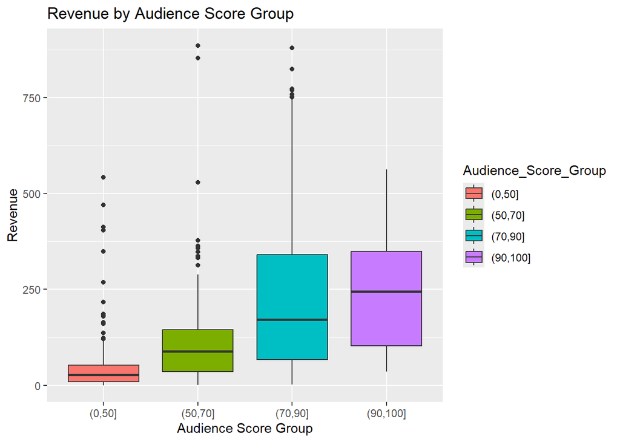

```r
  #3. Revenue by Audience Scores
  df %>%
    mutate(Audience_Score_Group = cut(audience_score, breaks = c(0, 50, 70, 90, 100))) %>%

    ##Box Plot: Revenue by Audience Score Group
    ggplot(aes(x = Audience_Score_Group, y = revenue, fill = Audience_Score_Group)) +
    geom_boxplot() +
    labs(title = "Revenue by Audience Score Group", x = "Audience Score Group", y = "Revenue")
```

Additionally, we want to see if best picture nominations have an impact on the revenue and profits which would result in different strategies.

```r
# Calculate average revenue by genre and Best Picture nomination
  genre_revenue <- df %>%
    group_by(genre_category, best_pic_nom) %>%
    summarise(avg_revenue = mean(revenue, na.rm = TRUE))
```

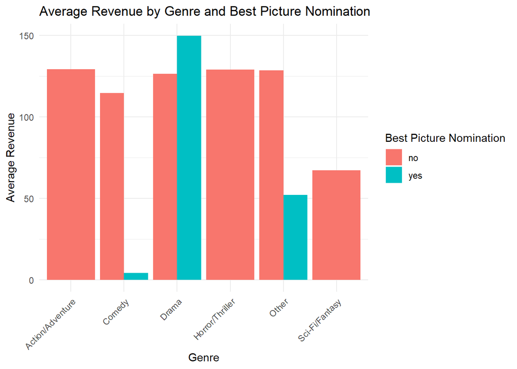

```r
  # Bar chart: Average Revenue by Genre and Best Picture Nomination
  ggplot(genre_revenue, aes(x = genre_category, y = avg_revenue, fill = best_pic_nom)) +
    geom_bar(stat = "identity", position = "dodge") +
    labs(x = "Genre", y = "Average Revenue", fill = "Best Picture Nomination",
         title = "Average Revenue by Genre and Best Picture Nomination") +
    theme_minimal() +
    theme(axis.text.x = element_text(angle = 45, hjust = 1))
```

We have a general idea of our revenue drivers, next we want to answer the specific questions asked by the producers

```r
 #1. Do some genres generate more revenue?
    ## Average revenue by genre
    df %>%
    group_by(genre_category) %>%
    summarise(avg_revenue = mean(revenue, na.rm = TRUE)) %>%
    arrange(desc(avg_revenue))
```

```
## # A tibble: 6 × 2
##   genre_category   avg_revenue
##   <chr>                  <dbl>
## 1 Action/Adventure       129.
## 2 Horror/Thriller        129.
## 3 Drama                  128.
## 4 Other                  126.
## 5 Comedy                 113.
## 6 Sci-Fi/Fantasy          67.2
```

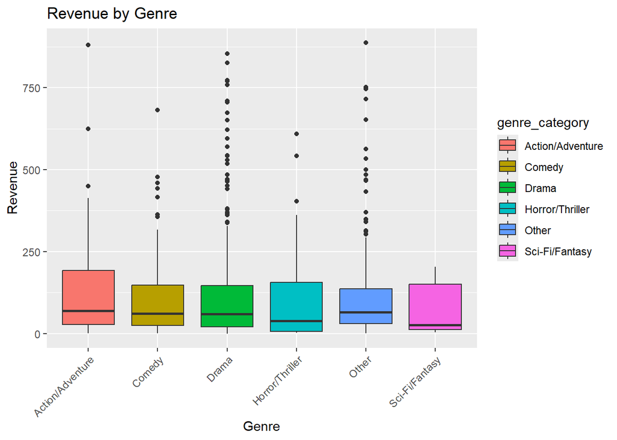

```r
  ## Box plot: Revenue by Genre
  ggplot(df, aes(x = genre_category, y = revenue, fill = genre_category)) +
    geom_boxplot() +
    labs(title = "Revenue by Genre", x = "Genre", y = "Revenue") +
    theme(axis.text.x = element_text(angle = 45, hjust = 1))
```

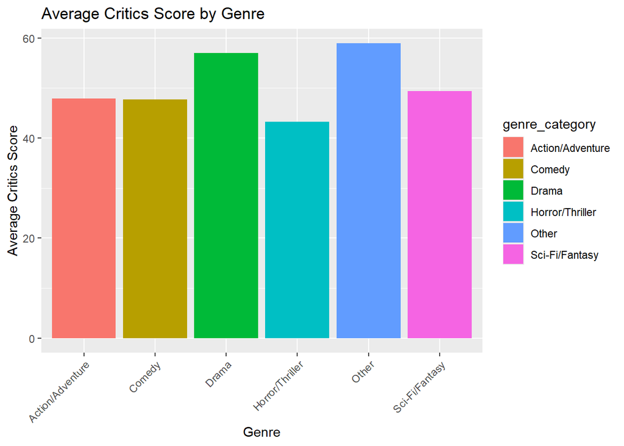

```r
  #2. Do critics have a typical preference for some particular genres?
  ## Average critics score by genre
  df %>%
    group_by(genre_category) %>%
    summarise(avg_critics_score = mean(critics_score, na.rm = TRUE)) %>%

    ## Bar chart: Average critics score by Genre
    ggplot(aes(x = genre_category, y = avg_critics_score, fill = genre_category)) +
    geom_bar(stat = "identity") +
    labs(title = "Average Critics Score by Genre", x = "Genre", y = "Average Critics Score") +
    theme(axis.text.x = element_text(angle = 45, hjust = 1))
```

```r
  #3. Is a critic score for a movie more important than the audience score.
  ##First we get the correlation of the critic scores with the revenue
  cor(df$critics_score, df$revenue, use = "complete.obs")
```

```
## [1] 0.4030977
```

```r
  ##Critics score has a moderately positive correlation with revenue - 0.4030977

  ##Correlation between the audience score with the revenue
  cor(df$audience_score, df$revenue, use = "complete.obs")
```

```
## [1] 0.4749107
```

```r
  ##Audience scores has a slightly stronger positive correlation with revenue - 0.4749107
```

# Predictive Analysis - Base Model

We want to leverage data from past movie releases to forecast the performance of future releases

Specifically, we are interested in seeing how different independent variables can predict the dependent variable of revenue. These analyses will enable the studio to anticipate how its films will perform as well as to proactively influence films towards commercial success

We will use multiple linear regression to build a predictive model

We begin by identifying categorical variables in the dataset and formatting them so that they can be included in the regression analysis

```r
##These are the non-numeric variables which are classified into discrete categories / groups.
    ##We format the variables as factors except in the case of best_pic_nom (where we simply code "yes" as 1 and "no" as 0)

    str(df)
```

```
## 'data.frame':    637 obs. of  22 variables:
##  $ title               : chr  "The Departed" "Exodus: Gods and Kings" "Spectre" "The X Files" ...
##  $ type                : chr  "Feature Film" "Feature Film" "Feature Film" "Feature Film" ...
##  $ genre               : chr  "Drama" "Drama" "Comedy" "Drama" ...
##  $ runtime             : num  118 131 84 97 78 107 130 100 127 110 ...
##  $ mpaa_rating         : chr  "Unrated" "PG-13" "R" "PG" ...
##  $ imdb_rating         : num  2.1 3.3 7.6 2.5 7.8 2.1 2.1 4.1 6.8 2.1 ...
##  $ imdb_num_votes      : num  9904 1010 22381 54363 333 ...
##  $ critics_rating      : chr  "Fresh" "Fresh" "Certified Fresh" "Rotten" ...
##  $ critics_score       : num  10 43 91 27 91 30 33 56 89 30 ...
##  $ audience_rating     : chr  "Upright" "Upright" "Upright" "Upright" ...
##  $ audience_score      : num  21 34 91 23 86 21 31 45 75 21 ...
##  $ best_pic_nom        : chr  "no" "no" "no" "no" ...
##  $ Facebook_Likes      : num  48 490 11700 230 211873 ...
##  $ budget              : num  1 2 110 2.9 135 1 2 2 245 3.15 ...
##  $ revenue             : num  9.32e-03 4.54e-02 2.95e+02 2.97e-01 5.33e+02 ...
##  $ language            : chr  "English" "English" "English" "English" ...
##  $ country             : chr  "USA" "UK" "UK" "USA" ...
##  $ profit              : num  -0.991 -1.955 185.238 -2.603 397.951 ...
##  $ critics_score_scaled: num  1 4.3 9.1 2.7 9.1 3 3.3 5.6 8.9 3 ...
##  $ avg_rating          : num  1.55 3.8 8.35 2.6 8.45 2.55 2.7 4.85 7.85 2.55 ...
##  $ ROI                 : num  -99.1 -97.7 168.4 -89.8 294.8 ...
##  $ genre_category      : chr  "Drama" "Drama" "Comedy" "Drama" ...
```

```r
    df <- df %>%
      mutate(
        type = as.factor(type),
        genre_category = as.factor(genre_category),
        mpaa_rating = as.factor(mpaa_rating),
        critics_rating = as.factor(critics_rating),
        audience_rating = as.factor(audience_rating),
        language = as.factor(language),
        country = as.factor(country),
        best_pic_nom = ifelse(best_pic_nom == "yes", 1, 0)
      )

    str(df)
```

```
## 'data.frame':    637 obs. of  22 variables:
##  $ title               : chr  "The Departed" "Exodus: Gods and Kings" "Spectre" "The X Files" ...
##  $ type                : Factor w/ 3 levels "Documentary",..: 2 2 2 2 1 2 2 2 2 2 ...
##  $ genre               : chr  "Drama" "Drama" "Comedy" "Drama" ...
##  $ runtime             : num  118 131 84 97 78 107 130 100 127 110 ...
##  $ mpaa_rating         : Factor w/ 6 levels "G","NC-17","PG",..: 6 4 5 3 6 5 5 5 3 3 ...
##  $ imdb_rating         : num  2.1 3.3 7.6 2.5 7.8 2.1 2.1 4.1 6.8 2.1 ...
##  $ imdb_num_votes      : num  9904 1010 22381 54363 333 ...
##  $ critics_rating      : Factor w/ 3 levels "Certified Fresh",..: 2 2 1 3 2 2 1 2 1 2 ...
##  $ critics_score       : num  10 43 91 27 91 30 33 56 89 30 ...
##  $ audience_rating     : Factor w/ 2 levels "Spilled","Upright": 2 2 2 2 2 2 2 2 2 2 ...
##  $ audience_score      : num  21 34 91 23 86 21 31 45 75 21 ...
##  $ best_pic_nom        : num  0 0 0 0 0 0 0 0 0 0 ...
##  $ Facebook_Likes      : num  48 490 11700 230 211873 ...
##  $ budget              : num  1 2 110 2.9 135 1 2 2 245 3.15 ...
##  $ revenue             : num  9.32e-03 4.54e-02 2.95e+02 2.97e-01 5.33e+02 ...
##  $ language            : Factor w/ 5 levels "English","French",..: 1 1 1 1 1 1 1 1 1 1 ...
##  $ country             : Factor w/ 13 levels "Australia","Belgium",..: 13 12 12 13 13 13 13 13 13 13 ...
##  $ profit              : num  -0.991 -1.955 185.238 -2.603 397.951 ...
##  $ critics_score_scaled: num  1 4.3 9.1 2.7 9.1 3 3.3 5.6 8.9 3 ...
##  $ avg_rating          : num  1.55 3.8 8.35 2.6 8.45 2.55 2.7 4.85 7.85 2.55 ...
##  $ ROI                 : num  -99.1 -97.7 168.4 -89.8 294.8 ...
##  $ genre_category      : Factor w/ 6 levels "Action/Adventure",..: 3 3 2 3 5 3 3 3 1 3 ...
```

```r
  #With the categorical variables formatted as factors, they can be incorporated into the model as dummy variables
```

We can now choose which variables to include in our linear regression model

There are many variables in our dataset. Existing research regarding the film industry and our own judgement provide a starting point for variables to include in our model.

Amongst film characteristics discussed in the text “Predicting Movie Success at the Box Office” - see Note 1 at end of code - budget, genre, awards, critics’ reviews and audience opinions are represented within our dataset.

We will be conducting in-depth genre analyses after our initial regression model is created, so we will exclude genre from our model at this stage

We will use best_pic_nom to examine the impact of awards

We will use critics_score to examine the impact of critics’ reviews

Given the strong correlation observed between critics_score and audience_score, we will be sure to exclude audience scores from our model to avoid multicollinearity.

Instead, we will use Facebook likes to gauge audience opinions. We believe Facebook Likes may be a valuable characteristic, because it could capture early attitudes towards an unreleased film. I.e., before the public has had an opportunity to view and/or review the film

```r
  #Therefore, we test "budget, "best_pic_nom", "critics_score", and "Facebook_Likes" as independent variables in our model with revenue as a dependent variable
    ##We applied a model intercept of 0, as a film with no budget and no viewer response will likely not earn revenue
    model <- lm(revenue ~ budget + best_pic_nom + critics_score + Facebook_Likes + 0, data=df)
```

We will also apply best rpactices and check that fundamental assumptions of linear regressions hold for this model